# 20_projection_3D_to_2D

## 20_projection_3D_to_2D

#### Question

1. A video-game developer is hoping to apply an [oblique projection](https://en.wikipedia.org/wiki/Oblique_projection) to show a set of 3D points as a 2D image. The starting points are stored as rows in a 5 $\times$ 3 matrix $S$.

   $$S=\begin{bmatrix}
   1.1083 & 0.6921 & 1.1369\\
   1.6243 & -0.3065 & -0.5174\\
   0.2532 & 0.7108 & -1.5591\\
   -0.2628 & 1.7093 & 0.0952\\
   -0.6808 & -0.7014 & 0.2111
   \end{bmatrix}$$

   The oblique projection matrix $P$ has two key parameters: $\theta$ and $r$. For this problem, use $\theta=0.9987$ and $r=0.5106$.

   $$P~=~\begin{bmatrix}
   1 & 0\\
   0 & 1\\
   r\cdot\cos(\theta) & r\cdot\sin(\theta)
   \end{bmatrix}$$

   The final points (in matrix $F$) are found by multiplying $S\cdot P$.

   $$F=S\cdot P$$

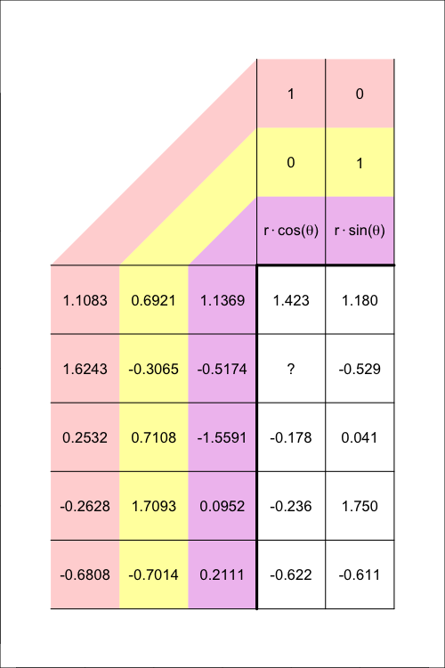

   What is the new $x$ coordinate when point $(1.6243, -0.3065, -0.5174)$ is projected using the oblique projection with $\theta=0.9987$ and $r=0.5106$?

#### Question

2. A video-game developer is hoping to apply an [oblique projection](https://en.wikipedia.org/wiki/Oblique_projection) to show a set of 3D points as a 2D image. The starting points are stored as rows in a 5 $\times$ 3 matrix $S$.

   $$S=\begin{bmatrix}
   0.97 & -1.4023 & -0.3043\\
   0.7215 & -0.5354 & 1.4808\\
   -1.244 & -0.3945 & 1.1388\\
   -0.9955 & -1.2614 & -0.6463\\
   0.137 & 0.8984 & -0.4172
   \end{bmatrix}$$

   The oblique projection matrix $P$ has two key parameters: $\theta$ and $r$. For this problem, use $\theta=0.5816$ and $r=0.5217$.

   $$P~=~\begin{bmatrix}
   1 & 0\\
   0 & 1\\
   r\cdot\cos(\theta) & r\cdot\sin(\theta)
   \end{bmatrix}$$

   The final points (in matrix $F$) are found by multiplying $S\cdot P$.

   $$F=S\cdot P$$

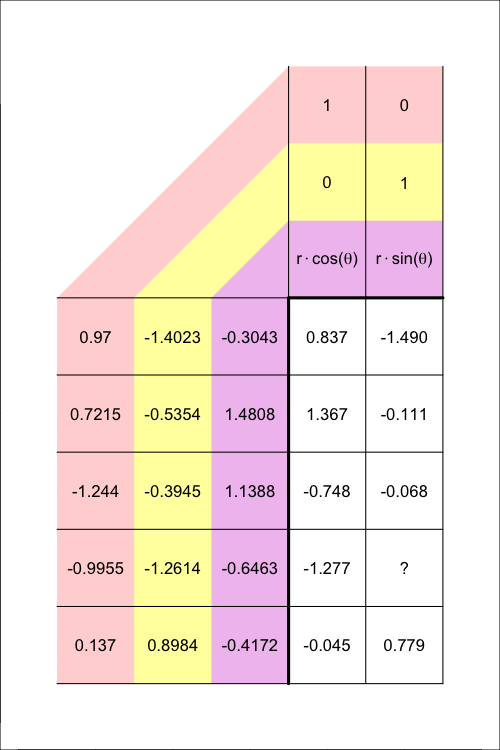

   What is the new $y$ coordinate when point $(-0.9955, -1.2614, -0.6463)$ is projected using the oblique projection with $\theta=0.5816$ and $r=0.5217$?

#### Question

3. A video-game developer is hoping to apply an [oblique projection](https://en.wikipedia.org/wiki/Oblique_projection) to show a set of 3D points as a 2D image. The starting points are stored as rows in a 5 $\times$ 3 matrix $S$.

   $$S=\begin{bmatrix}
   -1.5013 & 0.1966 & -0.8412\\
   -0.9327 & -1.4531 & 0.1362\\
   -0.3135 & -0.3303 & 1.6711\\
   -0.8821 & 1.3193 & 0.6937\\
   0.9074 & 0.0669 & -0.415
   \end{bmatrix}$$

   The oblique projection matrix $P$ has two key parameters: $\theta$ and $r$. For this problem, use $\theta=0.649$ and $r=0.3288$.

   $$P~=~\begin{bmatrix}
   1 & 0\\
   0 & 1\\
   r\cdot\cos(\theta) & r\cdot\sin(\theta)
   \end{bmatrix}$$

   The final points (in matrix $F$) are found by multiplying $S\cdot P$.

   $$F=S\cdot P$$

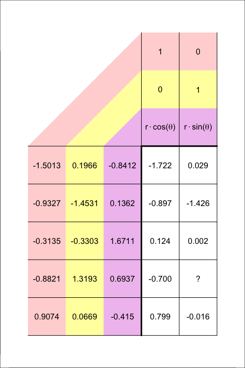

   What is the new $y$ coordinate when point $(-0.8821, 1.3193, 0.6937)$ is projected using the oblique projection with $\theta=0.649$ and $r=0.3288$?

#### Question

4. A video-game developer is hoping to apply an [oblique projection](https://en.wikipedia.org/wiki/Oblique_projection) to show a set of 3D points as a 2D image. The starting points are stored as rows in a 5 $\times$ 3 matrix $S$.

   $$S=\begin{bmatrix}
   -0.6862 & -1.5772 & -0.2038\\
   -0.9529 & -0.3991 & 1.3902\\
   -1.2703 & 1.1632 & 0.1825\\
   -1.0037 & -0.0149 & -1.4115\\
   0.9783 & 0.207 & 0.0106
   \end{bmatrix}$$

   The oblique projection matrix $P$ has two key parameters: $\theta$ and $r$. For this problem, use $\theta=0.7139$ and $r=0.5908$.

   $$P~=~\begin{bmatrix}
   1 & 0\\
   0 & 1\\
   r\cdot\cos(\theta) & r\cdot\sin(\theta)
   \end{bmatrix}$$

   The final points (in matrix $F$) are found by multiplying $S\cdot P$.

   $$F=S\cdot P$$

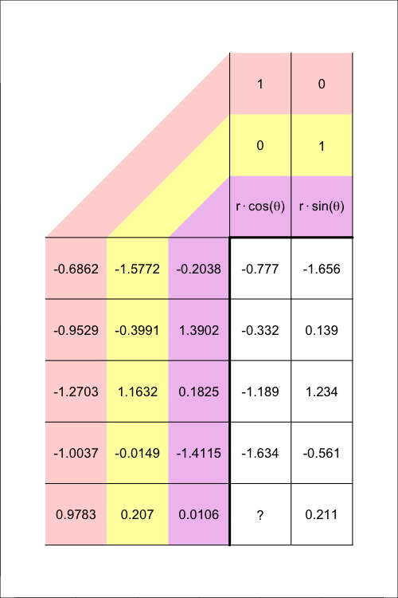

   What is the new $x$ coordinate when point $(0.9783, 0.207, 0.0106)$ is projected using the oblique projection with $\theta=0.7139$ and $r=0.5908$?

#### Question

5. A video-game developer is hoping to apply an [oblique projection](https://en.wikipedia.org/wiki/Oblique_projection) to show a set of 3D points as a 2D image. The starting points are stored as rows in a 5 $\times$ 3 matrix $S$.

   $$S=\begin{bmatrix}
   -0.2936 & 1.6586 & -0.4037\\
   -1.0666 & 0.6994 & 1.1719\\
   0.7265 & -0.0923 & 1.5696\\
   1.4995 & 0.8669 & -0.006\\
   -0.2164 & -0.7832 & -0.5829
   \end{bmatrix}$$

   The oblique projection matrix $P$ has two key parameters: $\theta$ and $r$. For this problem, use $\theta=0.9241$ and $r=0.2737$.

   $$P~=~\begin{bmatrix}
   1 & 0\\
   0 & 1\\
   r\cdot\cos(\theta) & r\cdot\sin(\theta)
   \end{bmatrix}$$

   The final points (in matrix $F$) are found by multiplying $S\cdot P$.

   $$F=S\cdot P$$

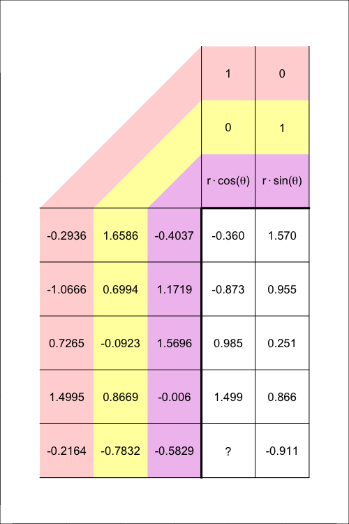

   What is the new $x$ coordinate when point $(-0.2164, -0.7832, -0.5829)$ is projected using the oblique projection with $\theta=0.9241$ and $r=0.2737$?

#### Question

6. A video-game developer is hoping to apply an [oblique projection](https://en.wikipedia.org/wiki/Oblique_projection) to show a set of 3D points as a 2D image. The starting points are stored as rows in a 5 $\times$ 3 matrix $S$.

   $$S=\begin{bmatrix}
   0.7141 & 0.3807 & -1.5314\\
   -0.1529 & 1.6987 & -0.302\\
   0.8097 & 0.8838 & 1.2503\\
   1.6766 & -0.4341 & 0.0209\\
   -0.7619 & -0.6323 & 0.1406
   \end{bmatrix}$$

   The oblique projection matrix $P$ has two key parameters: $\theta$ and $r$. For this problem, use $\theta=0.8972$ and $r=0.5813$.

   $$P~=~\begin{bmatrix}
   1 & 0\\
   0 & 1\\
   r\cdot\cos(\theta) & r\cdot\sin(\theta)
   \end{bmatrix}$$

   The final points (in matrix $F$) are found by multiplying $S\cdot P$.

   $$F=S\cdot P$$

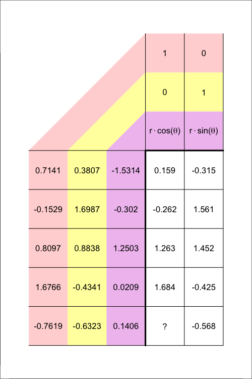

   What is the new $x$ coordinate when point $(-0.7619, -0.6323, 0.1406)$ is projected using the oblique projection with $\theta=0.8972$ and $r=0.5813$?

#### Question

7. A video-game developer is hoping to apply an [oblique projection](https://en.wikipedia.org/wiki/Oblique_projection) to show a set of 3D points as a 2D image. The starting points are stored as rows in a 5 $\times$ 3 matrix $S$.

   $$S=\begin{bmatrix}
   0.6979 & -1.5355 & -0.3939\\
   1.7107 & 0.0584 & 0.2646\\
   0.3148 & 0.3677 & 1.663\\
   -0.6981 & -1.2262 & 1.0046\\
   -0.5063 & 0.5839 & -0.6346
   \end{bmatrix}$$

   The oblique projection matrix $P$ has two key parameters: $\theta$ and $r$. For this problem, use $\theta=0.612$ and $r=0.5134$.

   $$P~=~\begin{bmatrix}
   1 & 0\\
   0 & 1\\
   r\cdot\cos(\theta) & r\cdot\sin(\theta)
   \end{bmatrix}$$

   The final points (in matrix $F$) are found by multiplying $S\cdot P$.

   $$F=S\cdot P$$

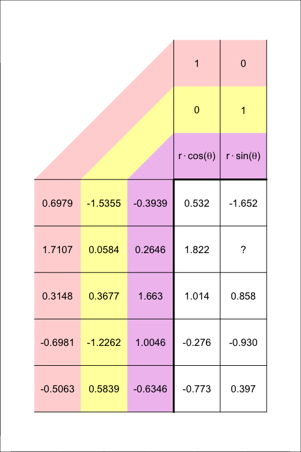

   What is the new $y$ coordinate when point $(1.7107, 0.0584, 0.2646)$ is projected using the oblique projection with $\theta=0.612$ and $r=0.5134$?

#### Question

8. A video-game developer is hoping to apply an [oblique projection](https://en.wikipedia.org/wiki/Oblique_projection) to show a set of 3D points as a 2D image. The starting points are stored as rows in a 5 $\times$ 3 matrix $S$.

   $$S=\begin{bmatrix}
   -0.6678 & -1.598 & -0.0215\\
   1.2645 & -1.1576 & 0.2471\\
   0.7563 & 0.2891 & 1.5312\\
   -1.1761 & -0.1513 & 1.2625\\
   -0.0442 & 0.6544 & -0.7548
   \end{bmatrix}$$

   The oblique projection matrix $P$ has two key parameters: $\theta$ and $r$. For this problem, use $\theta=0.6713$ and $r=0.3306$.

   $$P~=~\begin{bmatrix}
   1 & 0\\
   0 & 1\\
   r\cdot\cos(\theta) & r\cdot\sin(\theta)
   \end{bmatrix}$$

   The final points (in matrix $F$) are found by multiplying $S\cdot P$.

   $$F=S\cdot P$$

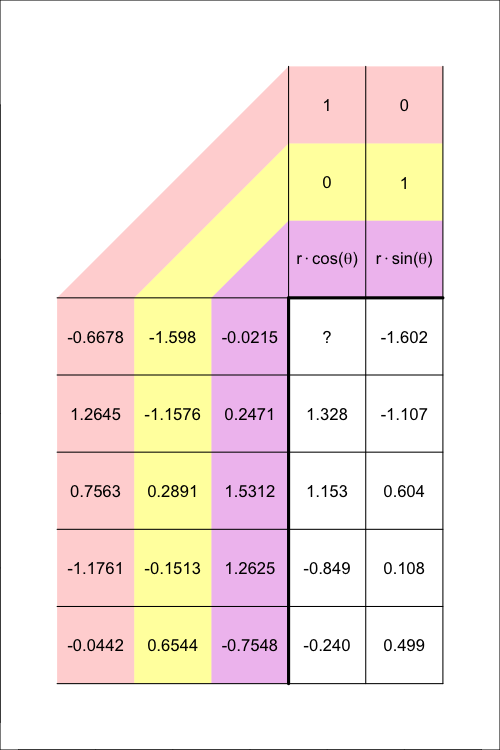

   What is the new $x$ coordinate when point $(-0.6678, -1.598, -0.0215)$ is projected using the oblique projection with $\theta=0.6713$ and $r=0.3306$?